# HW7 Regression

Rocco Matarazzo

2023-10-23

## Reading the Data

First, call the following packages: `ggplot2`, `tidyverse`, `readr`, `ggcorrplot`, and caret`. Now, we can read in our data:

```r
# Setting the File Path
fileName <-"C:/Users/rnm50/OneDrive/Documents/1A North Carolina State University/Fall 2023/ST558 Data Science/SeoulBikeData.csv"

# Read data
SeoulData <- read_csv(fileName, locale=locale(encoding="latin1"))
```

We need to include the argument for locale in order to fix the error when loading the file.

## Split the Data

Here we will split the data into a testing set and training set. The training set will contain 75% of the data. The testing set will contain 25% of the data.

```r
# setting seed so the sets stay consistent
set.seed(50)

# using dplyr
# assigning a number to each row in the dataset
SeoulData$number <- 1:nrow(SeoulData)

# Splitting the data into two sets
trainingIndex <- createDataPartition(SeoulData$`Rented Bike Count`, p=0.75, list=FALSE)

train <- SeoulData[trainingIndex,]
test <- SeoulData[-trainingIndex,]
```

## Data Cleaning & Pre-Processing

In this section we’ll clean and process the data by renaming some of the variables, removing unused variables, and adding a new variable. We must do the same cleaning and preprocessing on testing set that we are doing on the training set.

```r
# Remove the date variable (can be ignored per instructions)
testOne <- test %>%
  dplyr::select(-contains('date'))
trainOne <- train %>%
  dplyr::select(-contains('date'))

# Rename some columns
# I want to take out all the symbols
# I also want to make sure each variable has no spaces in between words
testTwo <-
  testOne %>% dplyr::rename(
  "RentedBikeCount" = "Rented Bike Count",
  "Temperature" = "Temperature(°C)",
  "Humidity" = "Humidity(%)",
  "WindSpeed" = "Wind speed (m/s)",
  "Visibility" = "Visibility (10m)",
  "DewPointTemp" = "Dew point temperature(°C)",
  "SolarRadiation" = "Solar Radiation (MJ/m2)",
  "Rainfall" = "Rainfall(mm)",
  "Snowfall" = "Snowfall (cm)",
  "FunctioningDay" = "Functioning Day"
)

trainTwo <-
  trainOne %>% dplyr::rename(
  "RentedBikeCount" = "Rented Bike Count",
  "Temperature" = "Temperature(°C)",
  "Humidity" = "Humidity(%)",
  "WindSpeed" = "Wind speed (m/s)",
  "Visibility" = "Visibility (10m)",
  "DewPointTemp" = "Dew point temperature(°C)",
  "SolarRadiation" = "Solar Radiation (MJ/m2)",
  "Rainfall" = "Rainfall(mm)",
  "Snowfall" = "Snowfall (cm)",
  "FunctioningDay" = "Functioning Day"
)

# Finally we'll create the new variable that we'll
# use in Logistic Regression
testFinal <- testTwo %>%
  dplyr::mutate(BikesRentedBinary = case_when(RentedBikeCount >= 650 ~ 1,
                        RentedBikeCount < 650  ~ 0))

trainFinal <- trainTwo %>%
  dplyr::mutate(BikesRentedBinary = case_when(RentedBikeCount >= 650 ~ 1,
                        RentedBikeCount < 650  ~ 0))
```

## Basic EDA

We’re mainly interested in our response variable RentedBikeCount. Although we got familiar with our variable names in the prior section, let’s first take a brief look at the data types we’re dealing with.

```r
# Print dataset
str(trainFinal)
```

```
## tibble [6,572 × 15] (S3: tbl_df/tbl/data.frame)
##  $ RentedBikeCount  : num [1:6572] 254 204 173 107 100 181 460 930 490 339 ...
##  $ Hour             : num [1:6572] 0 1 2 3 5 6 7 8 9 10 ...
##  $ Temperature      : num [1:6572] -5.2 -5.5 -6 -6.2 -6.4 -6.6 -7.4 -7.6 -6.5 -3.5 ...
##  $ Humidity         : num [1:6572] 37 38 39 40 37 35 38 37 27 24 ...
##  $ WindSpeed        : num [1:6572] 2.2 0.8 1 0.9 1.5 1.3 0.9 1.1 0.5 1.2 ...
##  $ Visibility       : num [1:6572] 2000 2000 2000 2000 2000 ...
##  $ DewPointTemp     : num [1:6572] -17.6 -17.6 -17.7 -17.6 -18.7 -19.5 -19.3 -19.8 -22.4 -21.2 ...
##  $ SolarRadiation   : num [1:6572] 0 0 0 0 0 0 0 0.01 0.23 0.65 ...
##  $ Rainfall         : num [1:6572] 0 0 0 0 0 0 0 0 0 0 ...
##  $ Snowfall         : num [1:6572] 0 0 0 0 0 0 0 0 0 0 ...
##  $ Seasons          : chr [1:6572] "Winter" "Winter" "Winter" "Winter" ...
##  $ Holiday          : chr [1:6572] "No Holiday" "No Holiday" "No Holiday" "No Holiday" ...
##  $ FunctioningDay   : chr [1:6572] "Yes" "Yes" "Yes" "Yes" ...
##  $ number           : int [1:6572] 1 2 3 4 6 7 8 9 10 11 ...
##  $ BikesRentedBinary: num [1:6572] 0 0 0 0 0 0 0 1 0 0 ...
```

It looks like we have several numerical variables, but there are also some categorical variables as well, such as Seasons, Holiday, and FunctioningDay.

Let’s briefly look at some contingency tables. To keep table simplicity, we’re going to use the binary Bikes Rented variable, where 1 is greater than or equal to 650 bikes rented, and 0 is less than 650 bikes rented.

```r
table(trainFinal$BikesRentedBinary, trainFinal$Seasons)
```

```
##
##     Autumn Spring Summer Winter
##   0    710    902    532   1592
##   1    902    795   1112     27
```

It seems that bikes pass the 650 threshold most often in the Summer and Autumn, and rarely in the Winter time.

Next, let’s explore correlation.

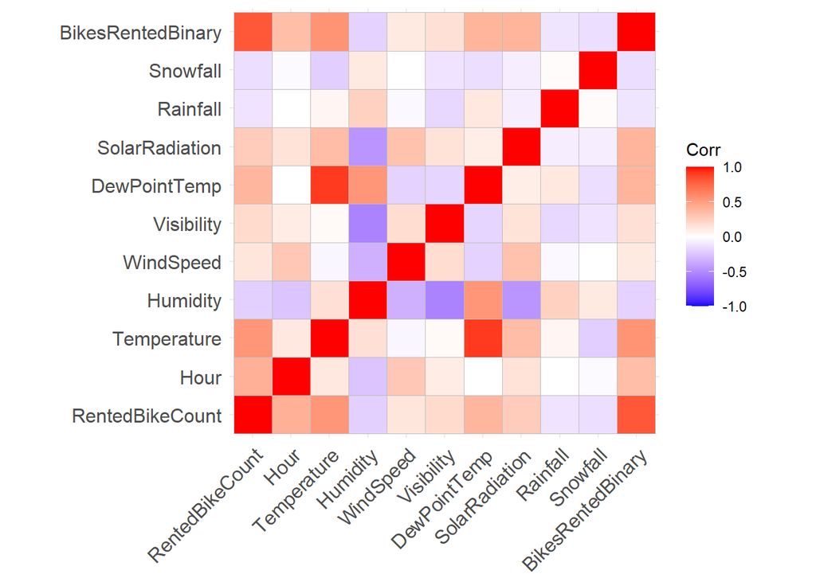

```r
# First we must remove non-numeric variables
correlation <- cor(trainFinal  %>%
                     dplyr::select(-Holiday, -'FunctioningDay', -number, -Seasons))

# Call ggcorrplot() function to get a pretty correlation plot
ggcorrplot(correlation)
```

Seemingly Temperature and Hour are the variables that correlate the most with the RentedBikeCount.

For the last step in this brief EDA, let’s look at a few scatterplots.

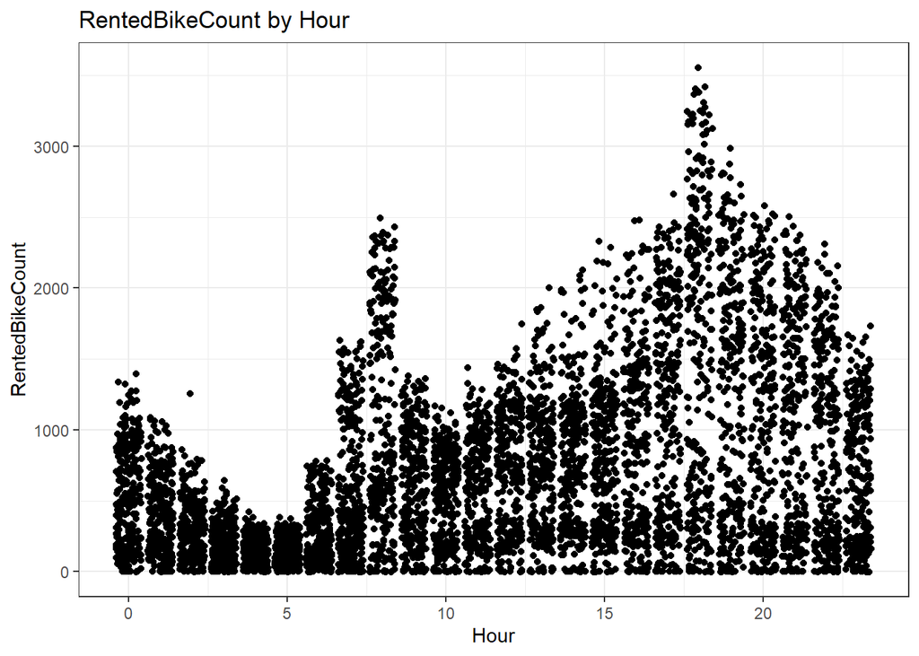

```r
ggplot(trainFinal, aes(x = Hour, y = RentedBikeCount)) +
  geom_jitter() +
  ggtitle("RentedBikeCount by Hour") +
  theme_bw()
```

This tells us the majority of bikes are rented later in the day.

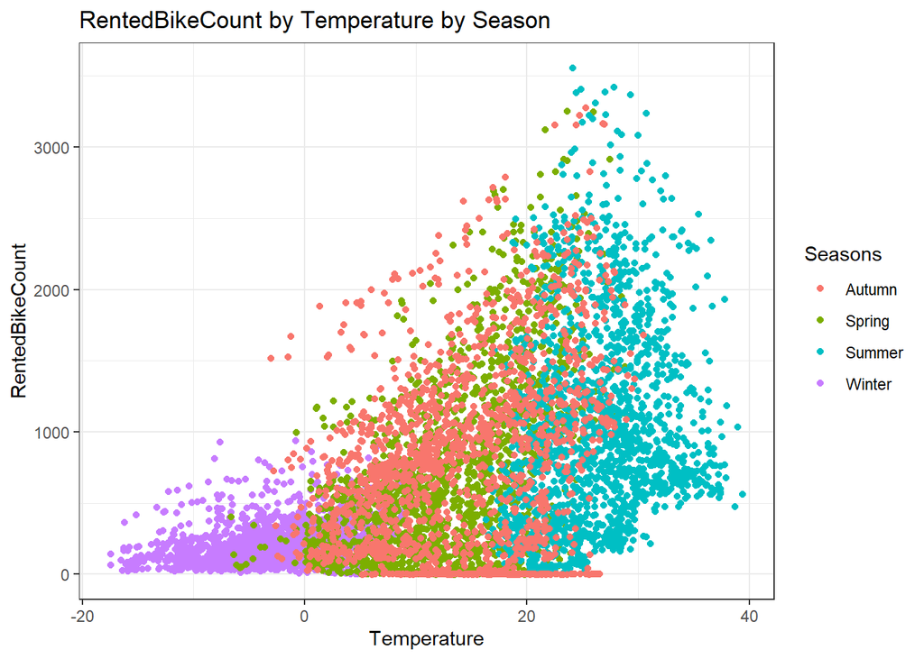

```r
ggplot(trainFinal, aes(x = Temperature, y = RentedBikeCount, col = Seasons)) +
  geom_jitter() +
  ggtitle("RentedBikeCount by Temperature by Season") +
  theme_bw()
```

This looks like that Temperature/Seasons are related to one another in terms of the number of bikes rented, which logically makes sense.

## Fitting MLR Models

Here we are going to fit three models. One via backwards selection, one via forwards selection, and one using LASSO regression. I’m going to use the following explanatory variables in each model, and let the model selection methods run their course:

#### Backwards + Forwards

I am going to hide the output from these codes because they’re quite lengthy!

```r
# forward selection
forwardSelection <-
  train(RentedBikeCount ~ Temperature + Rainfall + Visibility + factor(Seasons) + WindSpeed + Humidity,
        data = trainFinal %>% dplyr::select(-BikesRentedBinary),
        method = "lmStepAIC",
        direction = "forward")

# backward selection
backwardSelection <-
  train(RentedBikeCount ~ Temperature + Rainfall + Visibility + factor(Seasons) + WindSpeed + Humidity,
        data = trainFinal %>% dplyr::select(-BikesRentedBinary),
        method = "lmStepAIC",
        direction = "backward")
```

Here I will print the final model from each of the methods above.

**Forward Selection**

```r
bestForward <- forwardSelection$finalModel
bestForward
```

```
##
## Call:
## lm(formula = .outcome ~ Temperature + Rainfall + Visibility +
##     `factor(Seasons)Spring` + `factor(Seasons)Summer` + `factor(Seasons)Winter` +
##     WindSpeed + Humidity, data = dat)
##
## Coefficients:
##             (Intercept)              Temperature                 Rainfall
##                856.8803                  27.0383                 -49.5340
##              Visibility  `factor(Seasons)Spring`  `factor(Seasons)Summer`
##                  0.0028                 -56.0513                 -45.1511
## `factor(Seasons)Winter`                WindSpeed                 Humidity
##               -236.3081                  46.5275                  -8.4325
```

**Backward Selection**

```r
bestBackward <- backwardSelection$finalModel
bestBackward
```

```
##
## Call:
## lm(formula = .outcome ~ Temperature + Rainfall + `factor(Seasons)Spring` +
##     `factor(Seasons)Summer` + `factor(Seasons)Winter` + WindSpeed +
##     Humidity, data = dat)
##
## Coefficients:
##             (Intercept)              Temperature                 Rainfall
##                 864.326                   27.018                  -49.589
## `factor(Seasons)Spring`  `factor(Seasons)Summer`  `factor(Seasons)Winter`
##                 -56.986                  -44.773                 -237.439
##               WindSpeed                 Humidity
##                  46.581                   -8.481
```

### LASSO Regression

Here we will compute a LASSO regression model. We will use the same variables above while using cross-validation and tune the best lambda parameter.

```r
LASSO_Model <- train(RentedBikeCount ~ Temperature + Rainfall + Visibility + factor(Seasons) + WindSpeed + Humidity,
      data =  trainFinal %>% dplyr::select(-BikesRentedBinary ),
      method = "glmnet",
      trControl = trainControl(method = "cv"),
      tuneGrid = expand.grid(alpha = 1,
                              lambda = seq(0, 1, by = 0.05)))

# Pulling the best lamda
best_tuned_lambda <- LASSO_Model$bestTune$lambda

# Pulling the coefficients for the best model
bestLasso <- predict(LASSO_Model$finalModel,type="coef", s = best_tuned_lambda)
bestLasso
```

```
## 9 x 1 sparse Matrix of class "dgCMatrix"
##                                  s1
## (Intercept)            856.25123099
## Temperature             26.86408667
## Rainfall               -49.03780784
## Visibility               0.00265672
## factor(Seasons)Spring  -50.86221370
## factor(Seasons)Summer  -37.87357192
## factor(Seasons)Winter -233.68542672
## WindSpeed               45.74141107
## Humidity                -8.42318098
```

We can see that the best model for each method differ from one another. Now we have 3 models – a best Forward Selection model, a best Backwards Selection model, and a best LASSO regression model.

## Fitting Three *New* MLR Models

These models will include interaction and polynomial terms.

### Backwards + Forwards

Because visibility was dropped from the backwards method above, I am going to square that variable to see if a transformation has a different effect (only in the backwards selection formula). I’m also going to square Rainfall because of it’s original lack of correlation with the RentedBikeCount variable. As for other effects, I’m interested in the interaction between temperature and humidity, as well as temperature and seasons. My first model will have only interaction terms. The second model will have only polynomial terms. The third model will have both interaction and polynomial terms.

```r
# Only interactions
model_one <-
  train(RentedBikeCount ~ Temperature + Rainfall + Visibility + factor(Seasons) + WindSpeed + Humidity + Temperature:Humidity + Temperature:factor(Seasons),
        data = trainFinal %>% dplyr::select(-BikesRentedBinary),
        method = "lm",
        trControl = trainControl(method = "cv", number = 10))
# Storing final model
finalModelOne <- model_one$finalModel

# Only polynomials
model_two <-
  train(RentedBikeCount ~ Temperature + Rainfall + Visibility + factor(Seasons) + WindSpeed + Humidity + Visibility^2 + Rainfall^2,
        data = trainFinal %>% dplyr::select(-BikesRentedBinary),
        method = "lm",
        trControl = trainControl(method = "cv", number = 10))
# Storing final model
finalModelTwo <- model_two$finalModel

# Interactions and Polynomials
model_three <-
  train(RentedBikeCount ~ Temperature + Rainfall + Visibility + factor(Seasons) + WindSpeed + Humidity + Temperature:Humidity + Temperature:factor(Seasons) + Visibility^2 + Rainfall^2,
        data = trainFinal %>% dplyr::select(-BikesRentedBinary),
        method = "lm",
        trControl = trainControl(method = "cv", number = 10))

# Storing final model
finalModelThree <- model_three$finalModel
```

We can compare these models by checking out their results on the testing data.

```r
# Get the predicted values for each model
pred_M1 <- predict(finalModelOne, data = testFinal)
pred_M2 <- predict(finalModelTwo, data = testFinal)
pred_M3 <- predict(finalModelThree, data = testFinal)

# Calculating RMSE (Root Mean Sq. Error)
# This is a good measure of accuracy
RMSE_M1 <- RMSE(pred_M1, testFinal$RentedBikeCount)
RMSE_M2 <- RMSE(pred_M2, testFinal$RentedBikeCount)
RMSE_M3 <- RMSE(pred_M3, testFinal$RentedBikeCount)

paste("The RMSE for Model 1 is:", round(RMSE_M1, 2))
```

```
## [1] "The RMSE for Model 1 is: 757.01"
```

```r
paste("The RMSE for Model 2 is:", round(RMSE_M2, 2))
```

```
## [1] "The RMSE for Model 2 is: 754.94"
```

```r
paste("The RMSE for Model 3 is:", round(RMSE_M3, 2))
```

```
## [1] "The RMSE for Model 3 is: 757.01"
```

The best model of these 3 is model 2! It has the lowest RMSE. We will move forward with that one.

Now, we can take similar steps we did here for all 4 of our “best” models.

```r
# Get the predicted values for each model
# The best of the three int/poly models
pred_M2 <- predict(finalModelTwo, data = testFinal)

# The best forward selection model
pred_Forward <- predict(bestForward, data = testFinal)

# The best backward selection model
pred_backward <- predict(bestBackward, data = testFinal)

# The best LASSO selection model

# Pivoting the Data Wider for this model
# We need the data to be represented in matrix form
LASSO_Test <- testFinal %>%
  mutate(n = 1) %>%
  pivot_wider(names_from = Seasons, values_from = n, values_fill = list(n = 0)) %>%
  rename("SeasonsSpring" = "Spring",
         "SeasonsSummer" = "Summer",
         "SeasonsWinter" = "Winter") %>%
  dplyr::select(Temperature, Rainfall, Visibility, SeasonsSpring,
                SeasonsSummer, SeasonsWinter, WindSpeed, Humidity)

pred_LASSO <- predict(LASSO_Model$finalModel,
        newx = as.matrix(LASSO_Test),
        type = "response",
        s = best_tuned_lambda)


# Calculating RMSE (Root Mean Sq. Error)
# This is a good measure of accuracy
RMSE_LASSO <- RMSE(pred_LASSO, testFinal$RentedBikeCount)
RMSE_Forward <- RMSE(pred_Forward, testFinal$RentedBikeCount)
RMSE_Backward <- RMSE(pred_backward, testFinal$RentedBikeCount)
RMSE_M2 <- RMSE(pred_M2, testFinal$RentedBikeCount)

# Print results (descending fashion)
paste("The RMSE for the LASSO Model is:", round(RMSE_LASSO, 2))
```

```
## [1] "The RMSE for the LASSO Model is: 498.52"
```

```r
paste("The RMSE for Backward is:", round(RMSE_Backward, 2))
```

```
## [1] "The RMSE for Backward is: 754.92"
```

```r
paste("The RMSE for Model 2 (best of 3)  is:", round(RMSE_M2, 2))
```

```
## [1] "The RMSE for Model 2 (best of 3)  is: 754.94"
```

```r
paste("The RMSE for Forward Model is:", round(RMSE_Forward, 2))
```

```
## [1] "The RMSE for Forward Model is: 754.94"
```

The best Model is the LASSO model! It has the lowest RMSE.

## Fitting Logistic Models

Here we are going to fit three Logistic Regression models. Just like we did above, one will be fit via backwards selection, one via forwards selection, and one using LASSO regression. I’m going to use the following explanatory variables in each model, and let the model selection methods run their course:

The same reason for choosing these variables are as above.

### Backwards + Forwards

I am going to hide the output from these codes because they’re quite lengthy!

```r
# forward selection
forwardSelection_Logistic <-
  train(BikesRentedBinary  ~ Temperature + Rainfall + Visibility + factor(Seasons) + WindSpeed + Humidity,
        data = trainFinal %>% dplyr::select(-RentedBikeCount),
        method = "lmStepAIC",
        direction = "forward")

# backward selection
backwardSelection_Logistic <-
  train(BikesRentedBinary  ~ Temperature + Rainfall + Visibility + factor(Seasons) + WindSpeed + Humidity,
        data = trainFinal %>% dplyr::select(-RentedBikeCount),
        method = "lmStepAIC",
        direction = "backward")
```

Here I will print the final model from each of the methods above.

**Forward Selection**

```r
bestForward_LR <- forwardSelection_Logistic$finalModel
bestForward_LR
```

```
##
## Call:
## lm(formula = .outcome ~ Temperature + Rainfall + Visibility +
##     `factor(Seasons)Spring` + `factor(Seasons)Summer` + `factor(Seasons)Winter` +
##     WindSpeed + Humidity, data = dat)
##
## Coefficients:
##             (Intercept)              Temperature                 Rainfall
##               7.733e-01                1.773e-02               -3.260e-02
##              Visibility  `factor(Seasons)Spring`  `factor(Seasons)Summer`
##              -4.145e-05               -9.857e-02               -6.790e-02
## `factor(Seasons)Winter`                WindSpeed                 Humidity
##              -3.433e-01                3.197e-02               -7.440e-03
```

**Backward Selection**

```r
bestBackward_LR <- backwardSelection_Logistic$finalModel
bestBackward_LR
```

```
##
## Call:
## lm(formula = .outcome ~ Temperature + Rainfall + Visibility +
##     `factor(Seasons)Spring` + `factor(Seasons)Summer` + `factor(Seasons)Winter` +
##     WindSpeed + Humidity, data = dat)
##
## Coefficients:
##             (Intercept)              Temperature                 Rainfall
##               7.733e-01                1.773e-02               -3.260e-02
##              Visibility  `factor(Seasons)Spring`  `factor(Seasons)Summer`
##              -4.145e-05               -9.857e-02               -6.790e-02
## `factor(Seasons)Winter`                WindSpeed                 Humidity
##              -3.433e-01                3.197e-02               -7.440e-03
```

#### LASSO Regression

Here we will compute a LASSO regression model. We will use the same variables above while using cross-validation and tune the best lambda parameter.

```r
LASSO_Model_Logistic <- train(BikesRentedBinary  ~ Temperature + Rainfall + Visibility + factor(Seasons) + WindSpeed + Humidity,
      data = trainFinal %>% dplyr::select(-RentedBikeCount),
      method = "glmnet",
      trControl = trainControl(method = "cv"),
      tuneGrid = expand.grid(alpha = 1,
                              lambda = seq(0, 1, by = 0.05)))

# Pulling the best lamda
best_tuned_lambda_LR <- LASSO_Model_Logistic$bestTune$lambda

# Pulling the coefficients for the best model
bestLasso_LR <- predict(LASSO_Model_Logistic$finalModel,type="coef",
                        s = best_tuned_lambda_LR)
bestLasso_LR
```

```
## 9 x 1 sparse Matrix of class "dgCMatrix"
##                                  s1
## (Intercept)            7.654737e-01
## Temperature            1.763434e-02
## Rainfall              -3.222158e-02
## Visibility            -3.886294e-05
## factor(Seasons)Spring -9.397288e-02
## factor(Seasons)Summer -6.322236e-02
## factor(Seasons)Winter -3.401293e-01
## WindSpeed              3.138528e-02
## Humidity              -7.385770e-03
```

## Fitting Three *New* Logistic Regression Models

These models will include polynomial and interaction terms.

###### Backwards + Forwards

For model comparisons sake, I am going to use the same polynomial and interaction terms in this section.

```r
# Only interactions
model_one_LR <-
  train(BikesRentedBinary ~ Temperature + Rainfall + Visibility + factor(Seasons) + WindSpeed + Humidity + Temperature:Humidity + Temperature:factor(Seasons),
        data = trainFinal %>% dplyr::select(-RentedBikeCount),
        method = "lm",
        trControl = trainControl(method = "cv", number = 10))
# Storing final model
finalModelOne_LR <- model_one_LR$finalModel

# Only polynomials
model_two_LR <-
  train(BikesRentedBinary ~ Temperature + Rainfall + Visibility + factor(Seasons) + WindSpeed + Humidity + Visibility^2 + Rainfall^2,
        data = trainFinal %>% dplyr::select(-RentedBikeCount),
        method = "lm",
        trControl = trainControl(method = "cv", number = 10))
# Storing final model
finalModelTwo_LR <- model_two_LR$finalModel

# Interactions and Polynomials
model_three_LR <-
  train(BikesRentedBinary ~ Temperature + Rainfall + Visibility + factor(Seasons) + WindSpeed + Humidity + Temperature:Humidity + Temperature:factor(Seasons) + Visibility^2 + Rainfall^2,
        data = trainFinal %>% dplyr::select(-RentedBikeCount),
        method = "lm",
        trControl = trainControl(method = "cv", number = 10))

# Storing final model
finalModelThree_LR <- model_three_LR$finalModel
```

We can compare these models by checking out their results on the testing data.

```r
# Get the predicted values for each model
pred_M1_LR <- predict(finalModelOne_LR, data = testFinal)
pred_M2_LR <- predict(finalModelTwo_LR, data = testFinal)
pred_M3_LR <- predict(finalModelThree_LR, data = testFinal)

# Calculating RMSE (Root Mean Sq. Error)
# This is a good measure of accuracy
RMSE_M1_LR <- RMSE(pred_M1_LR, testFinal$BikesRentedBinary)
RMSE_M2_LR <- RMSE(pred_M2_LR, testFinal$BikesRentedBinary)
RMSE_M3_LR <- RMSE(pred_M3_LR, testFinal$BikesRentedBinary)

paste("The RMSE for Model 1 is:", round(RMSE_M1_LR, 2))
```

```
## [1] "The RMSE for Model 1 is: 0.59"
```

```r
paste("The RMSE for Model 2 is:", round(RMSE_M2_LR, 2))
```

```
## [1] "The RMSE for Model 2 is: 0.58"
```

```r
paste("The RMSE for Model 3 is:", round(RMSE_M3_LR, 2))
```

```
## [1] "The RMSE for Model 3 is: 0.59"
```

The best model of these 3 is model 2! It has the lowest RMSE. We will move forward with that one. I will print that model below.

```r
finalModelTwo_LR
```

```
##
## Call:
## lm(formula = .outcome ~ ., data = dat)
##
## Coefficients:
##             (Intercept)              Temperature                 Rainfall
##               7.733e-01                1.773e-02               -3.260e-02
##              Visibility  `factor(Seasons)Spring`  `factor(Seasons)Summer`
##              -4.145e-05               -9.857e-02               -6.790e-02
## `factor(Seasons)Winter`                WindSpeed                 Humidity
##              -3.433e-01                3.197e-02               -7.440e-03
```

Now, we can take similar steps we did here for all 4 of our “best” models.

```r
# Get the predicted values for each model
# The best of the three int/poly models
pred_M2_LR <- predict(finalModelTwo_LR, data = testFinal)

# The best forward selection model
pred_Forward_LR <- predict(bestForward_LR, data = testFinal)

# The best backward selection model
pred_backward_LR <- predict(bestBackward_LR, data = testFinal)

# The best LASSO selection model

# Pivoting the Data Wider for this model
# We need the data to be represented in matrix form
LASSO_Test <- testFinal %>%
  mutate(n = 1) %>%
  pivot_wider(names_from = Seasons, values_from = n, values_fill = list(n = 0)) %>%
  rename("SeasonsSpring" = "Spring",
         "SeasonsSummer" = "Summer",
         "SeasonsWinter" = "Winter") %>%
  dplyr::select(Temperature, Rainfall, Visibility, SeasonsSpring,
                SeasonsSummer, SeasonsWinter, WindSpeed, Humidity)

pred_LASSO_LR <- predict(LASSO_Model_Logistic$finalModel,
        newx = as.matrix(LASSO_Test),
        type = "response",
        s = best_tuned_lambda_LR)


# Calculating RMSE (Root Mean Sq. Error)
# This is a good measure of accuracy
RMSE_LASSO_LR <- RMSE(pred_LASSO_LR, testFinal$RentedBikeCount)
RMSE_Forward_LR <- RMSE(pred_Forward_LR, testFinal$RentedBikeCount)
RMSE_Backward_LR <- RMSE(pred_backward_LR, testFinal$RentedBikeCount)
RMSE_M2_LR <- RMSE(pred_M2_LR, testFinal$RentedBikeCount)

# Print results (descending fashion)
paste("The RMSE for the LASSO Model is:", round(RMSE_LASSO_LR, 3))
```

```
## [1] "The RMSE for the LASSO Model is: 944.002"
```

```r
paste("The RMSE for Backward is:", round(RMSE_Backward_LR, 3))
```

```
## [1] "The RMSE for Backward is: 943.65"
```

```r
paste("The RMSE for Model 2 (best of 3)  is:", round(RMSE_M2_LR, 3))
```

```
## [1] "The RMSE for Model 2 (best of 3)  is: 943.65"
```

```r
paste("The RMSE for Forward Model is:", round(RMSE_Forward_LR, 3))
```

```
## [1] "The RMSE for Forward Model is: 943.65"
```

The best model is Model 2/the Backward Model/the Forward model. Despite different model selections, and specifically the inclusions of polynomial terms in Model 2, the resulting models come out to be the same. That model slightly beats the LASSO regression model.

## Final Conclusion

The best model of the bunch was the LASSO Regression from the first section, based on RMSE. It had the lowest RMSE by over 250 units.